# Vigilancia de Infecciones Respiratorias Agudas

Autor/a

Dirección de Epidemiología

Fecha de publicación

17 de noviembre de 2025

El análisis de los eventos agrupados relacionados a la vigilancia de infecciones respiratorias agudas se realizó con los datos de aquellos establecimientos que notificaron al SNVS 2.0, por lo tanto, los N totales puede presentar una diferencia a lo publicado en semanas anteriores.

La notificación oportuna de los datos en SISA, permite optimizar la gestión de la información, la evaluación de la actividad y la toma de decisiones.

## **Vigilancia de virus respiratorios en internados y/o ambulatorios**

Determinaciones virales positivas. Chubut. SE 1- 41. Año 2025. (N= 383).

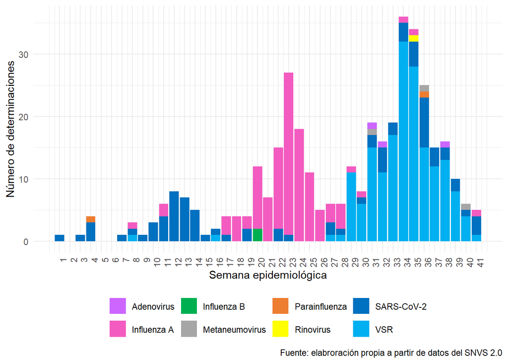

## **Vigilancia de virus respiratorios en ambulatorios**

Determinaciones virales positivas en ambulatorios según agente detectado. Chubut. SE 1- 41. Año 2025. (N= 102).

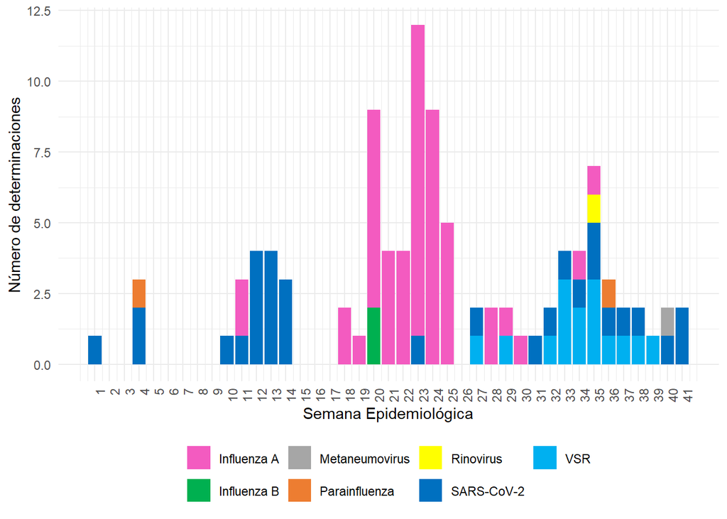

## **Vigilancia de virus respiratorios en internados**

A la semana 41 del año 2025 se identificaron 281 determinaciones positivas para virus respiratorios en los eventos “Internados y/o fallecido por COVID o IRA” y “Unidad Centinela de Infección Respiratoria Aguda Grave (UC-IRAG)”.

Determinaciones virales positivas en internados según agente detectado. Chubut. SE 1- 41. Año 2025. (N= 281).

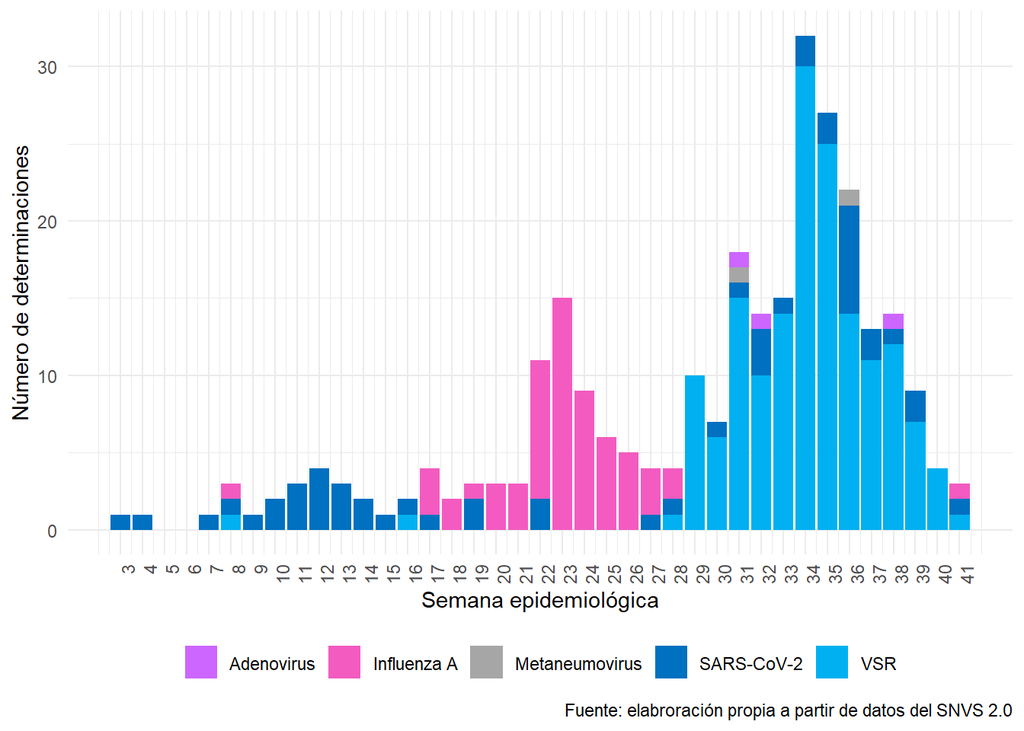

### **Distribución virus respiratorios por grupo etario en internados**

Determinaciones virales positivas por grupo etario y agente detectado. Chubut. SE 1- 41. Año 2025 (N= 281).

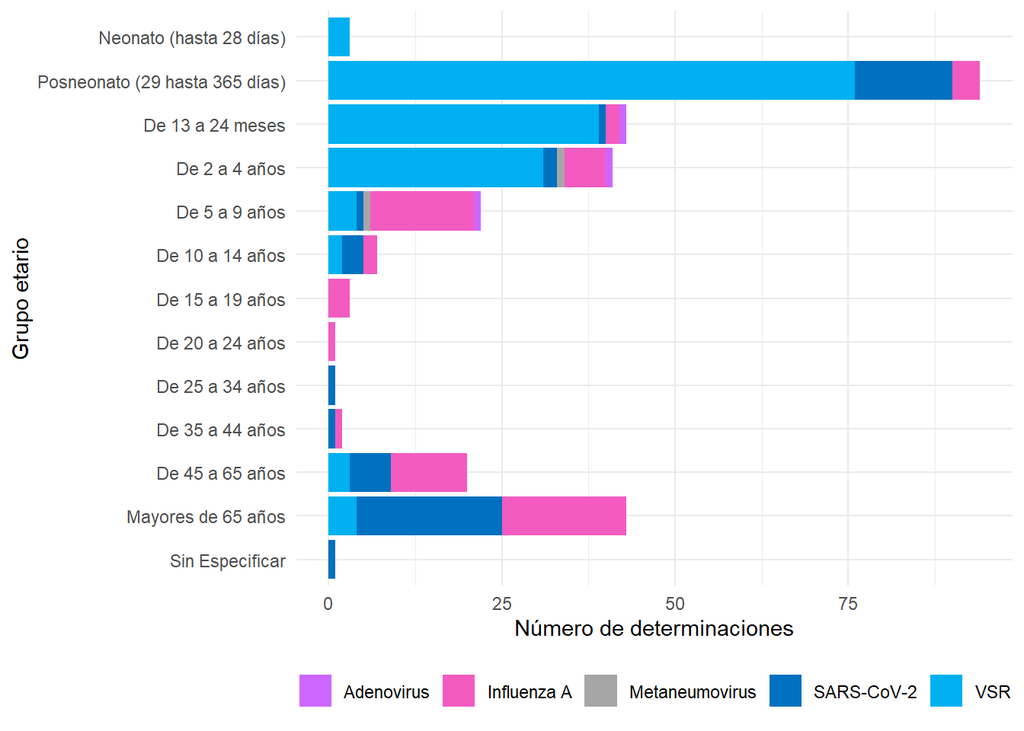

Entre las SE 1 y la SE 41 se registraron 281 determinaciones virales positivas en internados.

Para **VSR**, el grupo más afectado fue el de posneonato (29 hasta 365 días) con 76 determinaciones positivas. El **Sars-Cov-2** predominó en el grupo de mayores de 65 años con 21 determinaciones positivas. Por último, **Influenza A** predominó en el grupo de mayores de 65 años con 18 determinaciones positivas.